# Heterogeneous Treatment Effects II: Neural Networks

CML Week 6

2026-10-06

## Schedule

1. Design-based causal inference & Monte Carlo simulation
2. Covariate adjustment
3. Balancing weights
4. Double robustness, Double ML and TMLE
5. Heterogeneous Treatment Effects
6. **HTE II: Neural Networks**
7. Off-policy evaluation and optimization
8. Experimental design
9. Panel data and the new diff-in-diff
10. Partial Identification
11. Response adaptation
12. Interference

## The shift to neural networks

**Last time:** Tree-based methods (causal forests) and linear approaches (meta-learners)

- Random forests: interpretable, handle interactions naturally
- Meta-learners: flexible frameworks for combining models

**Why neural networks?**

- High-dimensional, structured covariates (text, images, complex tabular data)
- Can learn flexible representations
- Can incorporate specialized loss functions

**The challenge:** Standard deep learning is designed for prediction, not causal inference

- Need architectures and objectives tailored to estimating treatment effects
- Theoretical guarantees are critical (not just empirical performance)

## Challenges for deep learning in causal inference

**Challenge 1: No direct target for supervision**

- Supervised learning: observe $(X_i, Y_i)$ and minimize $\mathbb{E}[(Y - f(X))^2]$
- HTE estimation: never observe $\tau_i = Y_i(1) - Y_i(0)$
- Can’t directly optimize $\mathbb{E}[(\tau(X) - \hat{\tau}(X))^2]$

**Challenge 2: Incomparable representations**

- Naive approach: train separate networks $\hat{\mu}_1\left(\hlred{\Phi_1(x)}\right)$ and $\hat{\mu}_0\left(\hlred{\Phi_0(x)}\right)$
- Problem: networks learn different representations for treated vs control groups
- When computing $\hat{\tau}(x) = \hat{\mu}_1\left(\hlred{\Phi_1(x)}\right) - \hat{\mu}_0\left(\hlred{\Phi_0(x)}\right)$, we’re subtracting predictions from incomparable feature spaces

**Challenge 3: Distribution shift**

- Treated and control may have different covariate distributions
- Predicting counterfactual $Y_i(0)$ for treated unit requires extrapolation
- Neural networks can extrapolate poorly without explicit constraints

# (Shalit, Johansson, and Sontag 2017)

## Main contribution: Representation learning for ITE

**The solution:** Learn a *shared* representation $\Phi(x)$ that balances between:

1. **Predictive information:** $\Phi(x)$ retains information needed to predict $Y(0)$ and $Y(1)$
2. **Balance:** Treated and control distributions look similar in representation space

**The idea:**

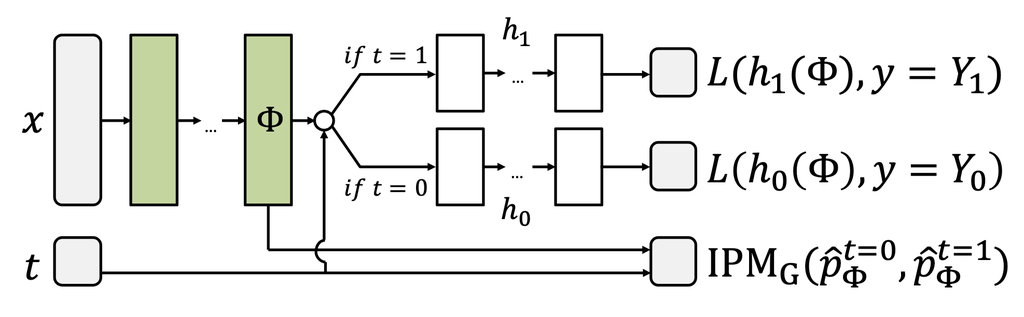

- Same representation $\hlblue{\Phi(x)}$ for both treatment arms
- Ensures predictions are made in a comparable feature space
- Estimate: $\hat{\tau}(x) = \hat{\mu}_1(\Phi(x)) - \hat{\mu}_0(\Phi(x))$

**Representational balance:** If treated and control are balanced in $\Phi(x)$ space, counterfactual predictions are reliable

## Balancing representations

**Why balance in representation space?**

- Original covariate space: treated and control may have very different distributions
- When predicting $Y_i(0)$ for a treated unit, we **extrapolate** to regions with no control
- Models may misbehave when extrapolating

**The balancing idea:**

- If $P(\Phi(X) \mid A=1) \approx P(\Phi(X) \mid A=0)$, then treated and control overlap *in representation space*
- Predictions $\hat{\mu}_0(\Phi(x))$ for treated units are no longer extrapolations

**The tradeoff:**

- Perfect balance: map everything to the same point $\Phi(x) = c$ for all $x$
  - Achieves balance but loses all predictive information!
- No balance: use all information $\Phi(x) = x$
  - Preserves information but may require wild extrapolation

## Theorem 1: Generalization bound (Setup)

**Question:** How well does our learned model estimate individual treatment effects?

**Setup:**

- Representation function: $\Phi: \mathcal{X} \to \mathcal{R}$
- Hypothesis class: $\mathcal{H}$ (functions from representation space to outcomes)
- Learned hypotheses: $h_0, h_1 \in \mathcal{H}$
- ITE estimate: $\hat{\tau}(x) = h_1(\Phi(x)) - h_0(\Phi(x))$

**The generalization bound relates three quantities:**

1. **Population ITE error:** $\epsilon_{\text{ITE}} = \mathbb{E}_{x \sim p}[|Y(1) - Y(0) - \hat{\tau}(x)|]$
   - What we care about but can’t directly measure
2. **Empirical factual error:** How well do $h_0, h_1$ predict observed outcomes?
   - What we can measure during training
3. **Representation distance:** $\text{disc}_{\mathcal{H}}(\Phi) = \sup_{h \in \mathcal{H}} |\mathbb{E}_{p_1}[h(\Phi(X))] - \mathbb{E}_{p_0}[h(\Phi(X))]|$
   - How different treated and control distributions look in $\Phi$ space

## Aside: Integral Probability Metrics (IPM)

**Definition:** An IPM measures the distance between two distributions $P$ and $Q$:

$$\text{IPM}_{\mathcal{F}}(P, Q) = \sup_{f \in \mathcal{F}} \left| \mathbb{E}_{X \sim P}[f(X)] - \mathbb{E}_{X \sim Q}[f(X)] \right|$$

- The choice of function class $\mathcal{F}$ determines the metric
- Larger $\mathcal{F}$ $\implies$ more discriminating distance

**Common choices:**

- **Maximum Mean Discrepancy (MMD):** $\mathcal{F}$ is the unit ball in a reproducing kernel Hilbert space (RKHS)
  - Computable in closed form using kernel trick
  - $\text{MMD}^2(P, Q) = \mathbb{E}[k(X, X')] - 2\mathbb{E}[k(X, Y)] + \mathbb{E}[k(Y, Y')]$ where $X \sim P, Y \sim Q$
- **Wasserstein distance:** $\mathcal{F}$ is the set of 1-Lipschitz functions
  - 1-Lipschitz: $|f(x) - f(y)| \leq \|x - y\|$ for all $x, y$ (bounded gradient)
  - Stronger metric that accounts for geometry of the space
  - Can be approximated using neural networks with gradient penalty

## Theorem 1: Generalization bound (Proof sketch)

**The bound:**

$$\epsilon_{\text{ITE}}(h_0, h_1, \Phi) \leq \epsilon_0(h_0, \Phi) + \epsilon_1(h_1, \Phi) + \lambda \cdot \text{disc}_{\mathcal{H}}(\Phi)$$

where $\epsilon_t$ is the prediction error for treatment group $t$.

**Proof intuition (for a single unit with $A=1$):**

Want to bound: $|Y(1) - Y(0) - \hat{\tau}(x)|$ where $\hat{\tau}(x) = h_1(\Phi(x)) - h_0(\Phi(x))$

$$\begin{align}
|Y(1) - Y(0) - \hat{\tau}(x)| &= |Y(1) - h_1(\Phi(x)) - (Y(0) - h_0(\Phi(x)))| \\
&\leq \underbrace{|Y(1) - h_1(\Phi(x))|}_{\text{factual error}} + \underbrace{|Y(0) - h_0(\Phi(x))|}_{\text{counterfactual error}}
\end{align}$$

**Key step:** How to bound the counterfactual error when we never observe $Y(0)$ for treated units?

- We can bound $\mathbb{E}_{A=0}[|Y(0) - h_0(\Phi(X))|]$ (error on control group)
- The IPM term $\text{disc}_{\mathcal{H}}(\Phi)$ bounds how much this changes when moving from control to treated distribution
- If representations are balanced, counterfactual error ≈ factual error on other group

## The invertibility of $\Phi$

**The condition:** $\Phi$ must be “invertible”

- Formally: There exists $\Psi$ such that $\Psi(\Phi(x)) = x$ for all $x$
- Intuition: No information is “thrown away” by the representation
- $\Phi(x_1) = \Phi(x_2)$ only if $x_1$ and $x_2$ have the same potential outcomes

**Why it’s needed:**

- Without invertibility: trivial solution $\Phi(x) = c$ for all $x$ achieves perfect balance!
  - Low IPM, but loses all predictive information about outcomes

**Is this realistic?**

- In practice, we *want* $\Phi$ to be a dimensionality reduction
- True invertibility means $\dim(\Phi(x)) \geq \dim(x)$ effectively
- Real implementations: use finite-dimensional representations and hope for “approximate invertibility”
- The theory guarantees don’t really hold in practice

**Practical takeaway:** Need representations that are rich enough to preserve predictive signal, but not so rich that balance is impossible

## The architecture

**Three components:**

1. **Representation network:** $\Phi: \mathcal{X} \to \mathcal{R}$ (shared)
2. **Hypothesis networks:** $h_0, h_1: \mathcal{R} \to \mathbb{R}$ (predict response surfaces)
3. **Discriminator/IPM network:** $\text{disc}_{\mathcal{H}}(\Phi)$ to enforce balance

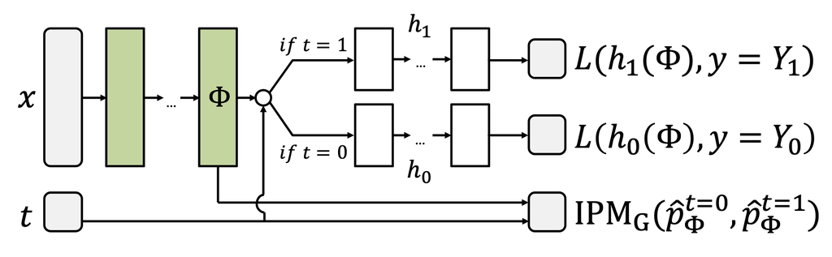

**Joint loss function:**

$$\begin{aligned}
\mathcal{L}(\Phi, h_0, h_1) = &\underbrace{\sum_{i: A_i=0} (Y_i - h_0(\Phi(X_i)))^2 + \sum_{i: A_i=1} (Y_i - h_1(\Phi(X_i)))^2}_{\text{Prediction error}} \\
&+ \alpha \cdot \underbrace{\text{IPM}(P_{\Phi}^{A=0}, P_{\Phi}^{A=1})}_{\text{Balance penalty}}
\end{aligned}$$

- $\alpha > 0$ controls the balance/prediction tradeoff
- Can use MMD, Wasserstein, or adversarial training to compute IPM
- Optimize jointly with respect to $\Phi, h_0, h_1$ (and discriminator parameters if using adversarial approach)

## Practical considerations

**Strengths:**

- **Principled approach:** Theoretical justification for representation learning
- **Flexibility:** Can adapt any neural architecture for $\Phi$, $h_0$, $h_1$
- **Explicit balance:** Directly targets the distribution shift problem
- **Influential work:** Spawned a large literature using representation learning

**Limitations:**

- **Hyperparameter sensitivity:** $\alpha$ tradeoff is critical but problem-specific (no principled way to choose)
- **Invertibility gap:** Practice uses dimensionality reduction
- **Computational cost:** Adversarial training or IPM computation adds overhead
- **Standard causal assumptions:** It isn’t magic
- **Bound may not be tight:** May not track the theoretical guarantees

**Verdict:** A major contribution, but take the bounds seriously but not literally

# (Shi, Blei, and Veitch 2019)

## Dragonnet architecture

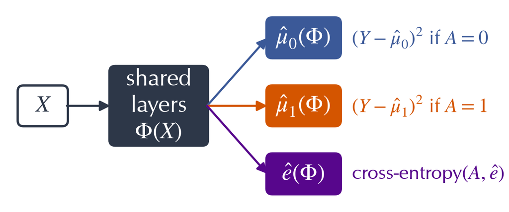

- Shared $\Phi(X)$ as before, plus a **third head** predicting treatment: $\hat{e}(\Phi) \approx e(X)$
- **Why:** adjusting for $e(X)$ alone is enough for identification, so $\Phi$ only *needs* the parts of $X$ that predict $A$. The propensity head pushes $\Phi$ to prioritise confounders, at some cost in pure outcome prediction
- Loss: $\;\mathcal{R}(\theta) = \frac{1}{n}\sum_i \Big[\big(Y_i - \hat{\mu}_{A_i}(X_i)\big)^2 + \alpha \cdot \text{CE}\big(A_i, \hat{e}(X_i)\big)\Big]$
- No IPM penalty: overlap is handled by estimating $\hat{e}$, not by forcing balance in $\Phi$

## Targeted regularisation is TMLE inside the loss

**Recall lecture 4:** Bang & Robins added $\hat{e}^{-1}$ as a regressor.

**Dragonnet:** a trainable scalar $\varepsilon$ on the clever covariate $H$, trained jointly with $\theta$:
$$\tilde{\mu}_a(x) = \hat{\mu}_a(x) + \varepsilon\, H(a, x), \qquad H(a, x) = \frac{a}{\hat{e}(x)} - \frac{1-a}{1-\hat{e}(x)}$$
$$\min_{\theta,\, \varepsilon} \; \mathcal{R}(\theta) + \beta \cdot \tfrac{1}{n}\textstyle\sum_i \big(Y_i - \tilde{\mu}_{A_i}(X_i)\big)^2$$

Only the second term involves $\varepsilon$, so its first-order condition holds exactly:
$$\textstyle\sum_i H(A_i, X_i)\big(Y_i - \tilde{\mu}_{A_i}(X_i)\big) = 0$$
The plug-in $\frac{1}{n}\sum_i [\tilde{\mu}_1(X_i) - \tilde{\mu}_0(X_i)]$ is then AIPW: the correction term is zero by construction.

- **TMLE** freezes $\hat{\mu}, \hat{e}$, then takes one step in $\varepsilon$. **Dragonnet** targets during training, so $\Phi$ moves too

## More to read

| Paper | Why you’d read it |
| --- | --- |
| (Koch et al. 2025) | The review that frames today: a primer on deep learning for causal inference, written for social scientists, with worked tutorials. |
| (Curth and van der Schaar 2021) | The CATE is often simpler than either potential outcome surface. Architectures that share information between $\mu_0$ and $\mu_1$ can exploit this. |
| (Ma et al. 2026) | Prior-data fitted networks: pretrain a transformer on simulated causal datasets, then estimate effects in-context on new data. |
| (Melnychuk et al. 2026) | PFNs carry a prior-induced bias that data never wash out. A one-step posterior correction makes them asymptotically match the efficient ATE estimator. |
| (Alaa and van der Schaar 2017) | Multi-task Gaussian processes over the potential outcomes, with posterior credible intervals for individual effects. |
| (Yoon, Jordon, and van der Schaar 2018) | GANITE: a GAN generates the missing counterfactuals, then a second network learns the ITE from the completed data. |
| (Louizos et al. 2017) | CEVAE: a variational autoencoder that infers latent confounders from noisy proxies. |

# References

Alaa, Ahmed M, and Mihaela van der Schaar. 2017. “Bayesian Inference of Individualized Treatment Effects Using Multi-Task Gaussian Processes.” *Advances in Neural Information Processing Systems* 30.

Curth, Alicia, and Mihaela van der Schaar. 2021. “On Inductive Biases for Heterogeneous Treatment Effect Estimation.” In *Advances in Neural Information Processing Systems*. Vol. 34.

Koch, Bernard, Tim Sainburg, Pablo Geraldo Bastías, Song Jiang, Yizhou Sun, and Jacob G Foster. 2025. “A Primer on Deep Learning for Causal Inference.” *Sociological Methods & Research* 54 (2): 397–447.

Louizos, Christos, Uri Shalit, Joris M Mooij, David Sontag, Richard Zemel, and Max Welling. 2017. “Causal Effect Inference with Deep Latent-Variable Models.” *Advances in Neural Information Processing Systems* 30.

Ma, Yiyang, Dennis Frauen, Elias Javurek, and Stefan Feuerriegel. 2026. “Foundation Models for Causal Inference via Prior-Data Fitted Networks.” In *International Conference on Learning Representations*.

Melnychuk, Valentyn, Vahid Balazadeh, Stefan Feuerriegel, and Rahul G Krishnan. 2026. “Frequentist Consistency of Prior-Data Fitted Networks for Causal Inference.” In *International Conference on Machine Learning*.

Shalit, Uri, Fredrik D Johansson, and David Sontag. 2017. “Estimating Individual Treatment Effect: Generalization Bounds and Algorithms.” In *International Conference on Machine Learning*, 3076–85. PMLR.

Shi, Claudia, David Blei, and Victor Veitch. 2019. “Adapting Neural Networks for the Estimation of Treatment Effects.” *Advances in Neural Information Processing Systems* 32.

Yoon, Jinsung, James Jordon, and Mihaela van der Schaar. 2018. “GANITE: Estimation of Individualized Treatment Effects Using Generative Adversarial Nets.” In *International Conference on Learning Representations*.